# StockResearch

Gabriel Foix

2020-11-03

Buy Quality at the a good momentum and get rid of the fishy stocks on time. That’s all.

### Factor 1: Quality

1. Healthy debts: A company shoud generate cash in order to repay its debt. The **Free Cash Flow to Debt** ratio is a good indicator of how quick a company pays back its debt. The lower this ratio the better.

FCF2D = $\frac{Debt}{Free Cash Flow}$

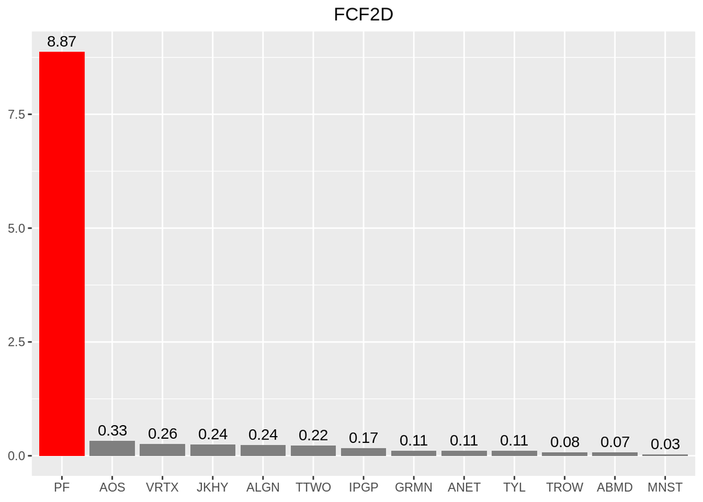

2. Profitability: ROA

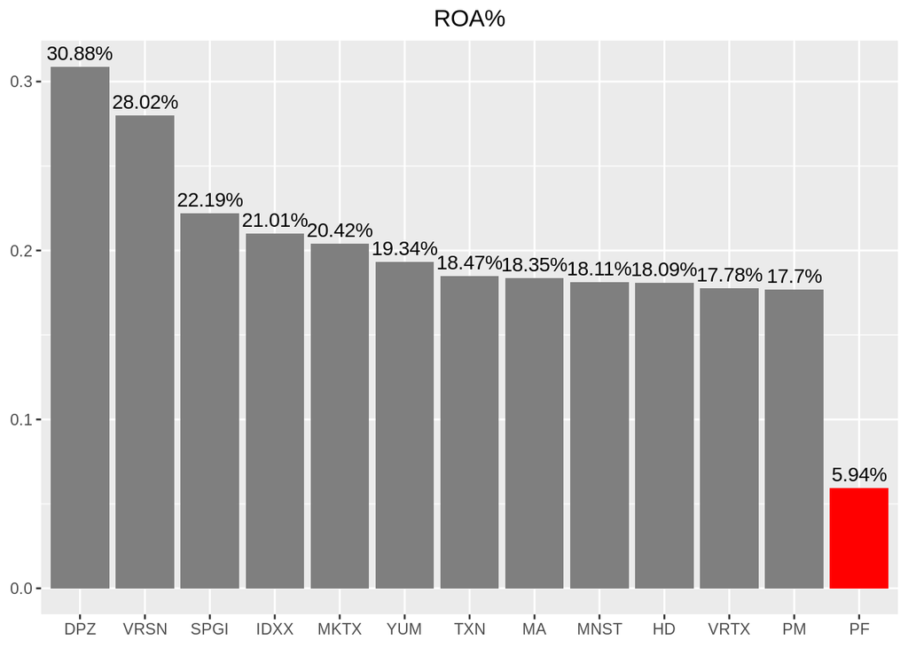

3. High Margin: We look for companies that generate free cash flow compare to its price. The **Free Cash Flow to Entreprise Value** ratio tells us how many years of cash flow would be needed to the return the 100% of the investment. Again, the lower, the better. Values bellow 1 would mean “free lunch”.

FCF2EV = $\frac{EV}{Free Cash Flow}$

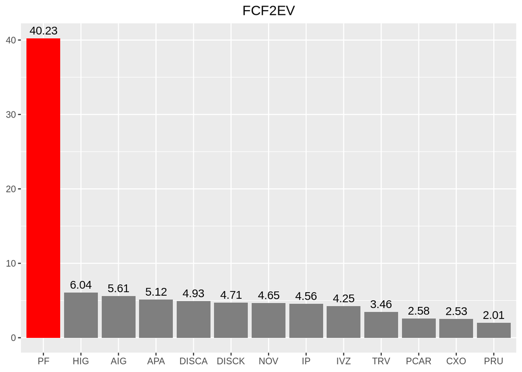

### Factor 2: Momentum

Don’t hold onto a stock simply because it is high quality. So called quality stocks have cycles too. Stan Weinstein (page 177)

Generic Intermediate-Term Momentum Based on Gray-Vogel (page 80)

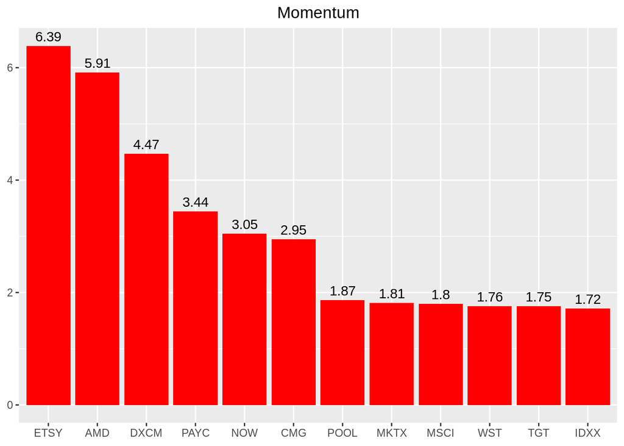

### Factor 3: Timing Signal

Sell Signal - Pr < 1% SMA 30 weeks and slope negative (< -0.2)  
Buy Signal - 109% * SMA30 < Pr > SMA 30 and slope positive (> 0.2)  
Hold Signal - Neither Buy nor Sell

### Summary

Summary

| Ticker | Signal | Quality | Momentum | Final_rank |
| --- | --- | --- | --- | --- |
| MKTX | BUY | 498.0 | 491 | 498.0 |
| CTLT | HOLD | 478.0 | 463 | 497.0 |
| AES | HOLD | 481.0 | 453 | 495.5 |
| PGR | BUY | 496.0 | 438 | 495.5 |
| BBY | HOLD | 483.0 | 448 | 494.0 |
| APD | BUY | 495.0 | 427 | 493.0 |
| FTNT | SELL | 436.0 | 485 | 492.0 |
| NFLX | HOLD | 417.0 | 481 | 491.0 |
| NEE | BUY | 450.0 | 443 | 490.0 |
| AWK | BUY | 475.0 | 417 | 489.0 |
| ZBRA | HOLD | 408.0 | 483 | 488.0 |
| LOW | BUY | 444.0 | 446 | 486.5 |
| NDAQ | HOLD | 493.0 | 397 | 486.5 |
| VAR | BUY | 494.0 | 383 | 485.0 |
| SBUX | BUY | 482.0 | 392 | 484.0 |
| TSCO | HOLD | 419.0 | 450 | 483.0 |
| SPGI | HOLD | 410.0 | 445 | 482.0 |
| WEC | BUY | 464.0 | 386 | 481.0 |
| TGT | HOLD | 360.0 | 488 | 480.0 |
| ACN | BUY | 466.5 | 381 | 479.0 |
| TER | BUY | 382.0 | 464 | 478.0 |
| AAPL | BUY | 359.0 | 486 | 477.0 |
| SWKS | HOLD | 486.0 | 352 | 476.0 |
| KLAC | BUY | 374.0 | 457 | 475.0 |
| ES | BUY | 463.0 | 364 | 474.0 |
| HD | BUY | 437.0 | 389 | 472.5 |
| VRTX | SELL | 469.0 | 357 | 472.5 |
| HCA | BUY | 449.0 | 374 | 470.5 |
| TT | HOLD | 365.0 | 458 | 470.5 |
| TROW | HOLD | 490.0 | 325 | 469.0 |

[output cut: 468 more lines]